# Joint conf-call report #2

### 100 samples GD test - RMSE over time

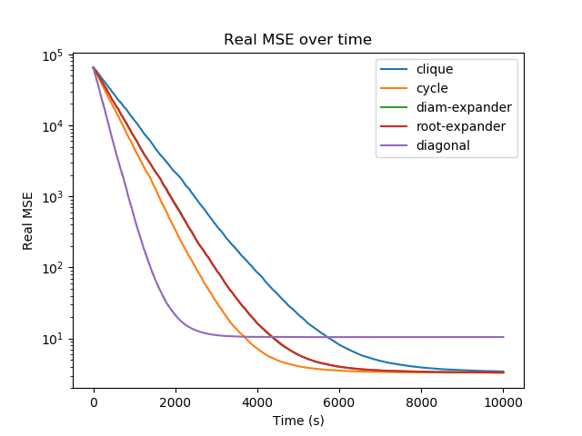

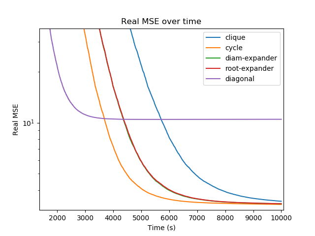

As already seen in previous plots for this test, diagonal topology, unlike all the others, never achieves a good prediction model.

The cycle turns out to be the fastest.

2-degree graphs plots (root expander and diameter expander) are very close.

*The same test with different seeds has led to almost identical results.*

## 1k samples GD test

`n_samples = 1000`.

### 1k samples GD test - iterations over time

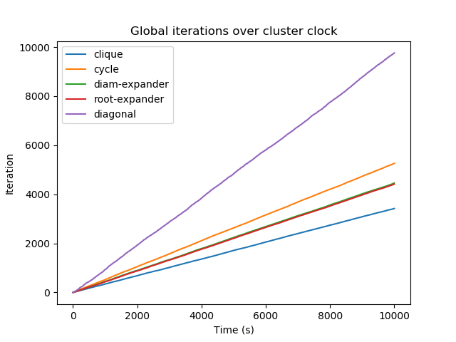

Almost the same result as in 100 samples test.

### 1k samples GD test - MSE over iterations

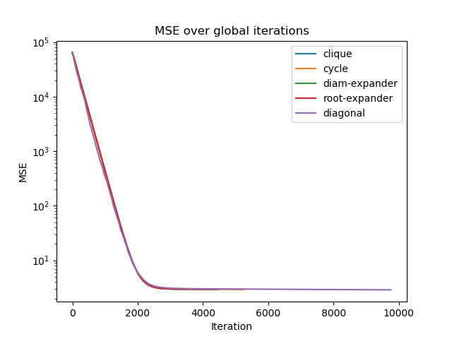

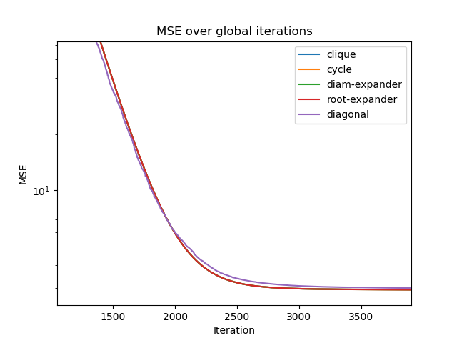

Now, since the amount of samples in the training set is equal to 1000, each node $i$ owns a subsample $\mathcal{X}_i \subset \mathcal{X}$ such that $|\mathcal{X}_i| = 100$ (when for $|\mathcal{X}|=100$, $|\mathcal{X}_i|=10$). Such condition seems enough for the diagonal topology to perform similarly as those with communications among nodes.

### 1k samples GD test - RMSE over iterations

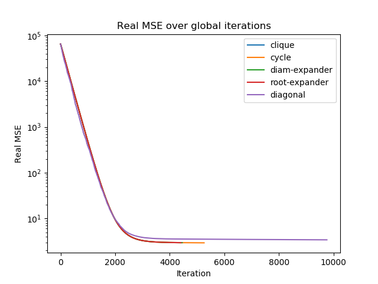

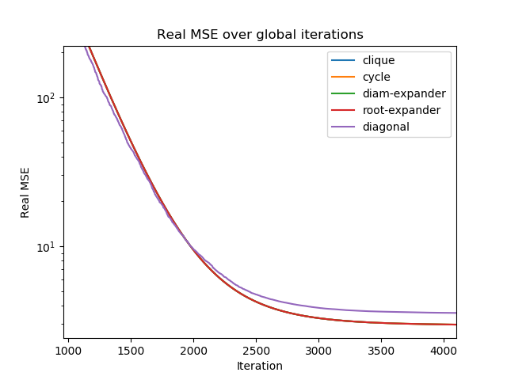

By comparing MSE/iter and RMSE/iter, we notice that diagonal topology suffers noise more than others topologies do.

### 1k samples GD test - MSE over time

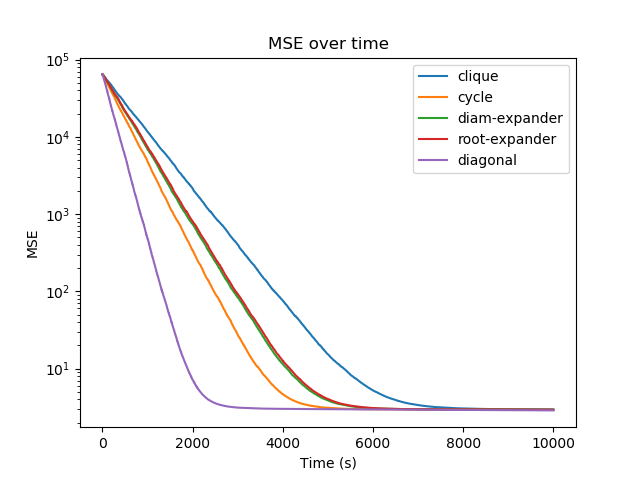

### 1k samples GD test - RMSE over time

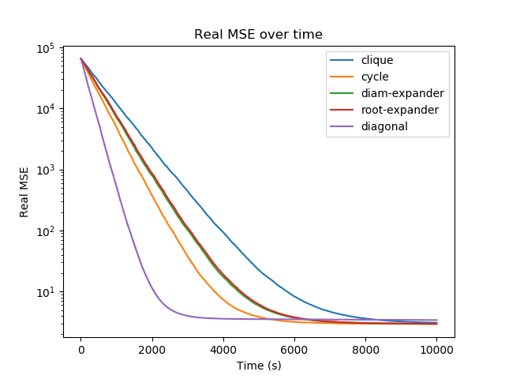

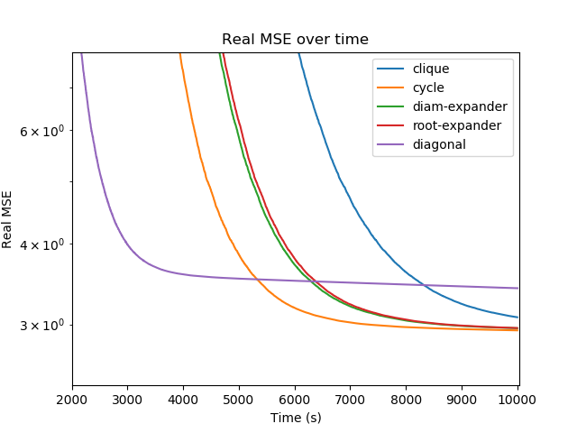

Despite the behaviour of topologies, with respect to **convergence speed**, is almost the same as the one observed in the *100 samples test MSE/time plot*, now diagonal topology doesn't behave so bad anymore (its error differs only by 1 from other topologies).

*The same test with different seeds has led to almost identical results.*

## 10k samples test

`n_samples = 10000`.

### 10k samples GD test - iterations over time

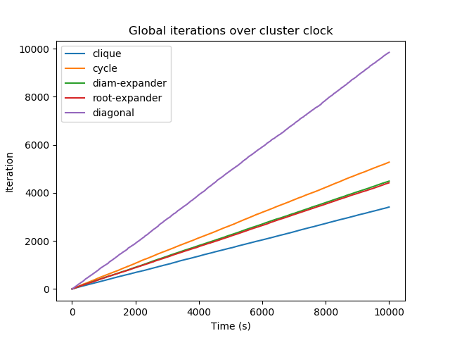

### 10k samples GD test - MSE over iterations

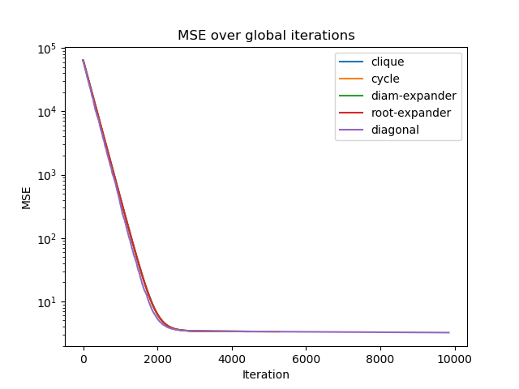

### 10k samples GD test - RMSE over iterations

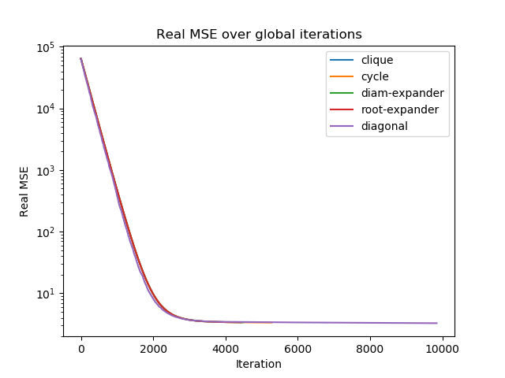

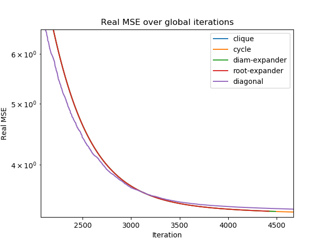

### 10k samples GD test - MSE over time

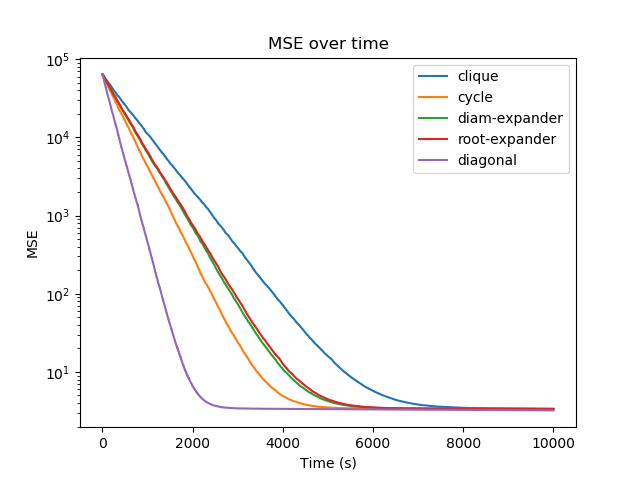

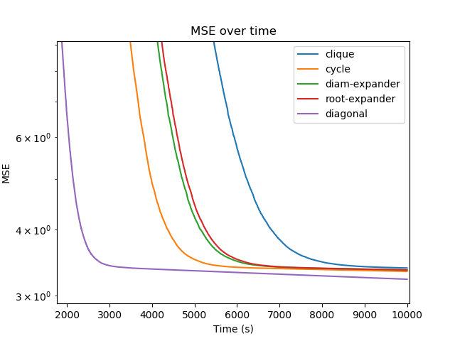

### 10k samples GD test - RMSE over time

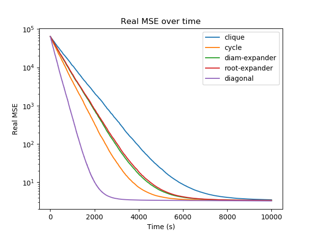

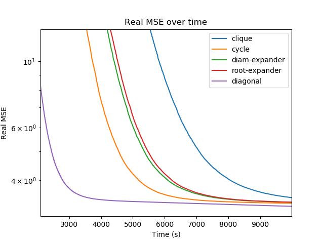

With $10000$ samples diagonal outperforms others topologies with regard to either MSE/time and RMSE/time plots.

*The same test with different seeds has led to almost identical results.*

## 100k samples GD test

`n_samples = 100000`.

### 100k samples GD test - iterations over time

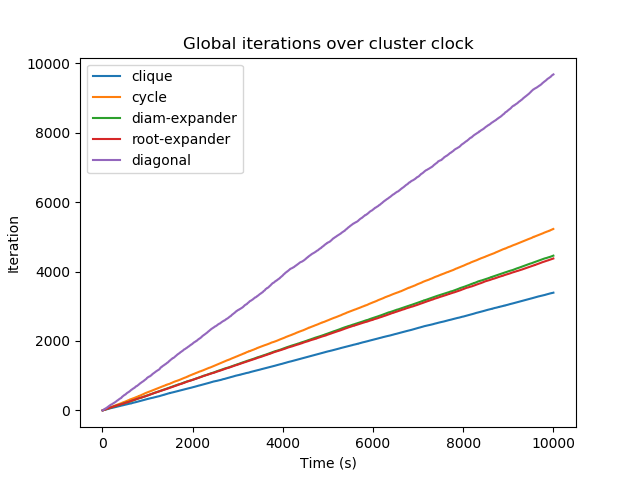

### 100k samples GD test - MSE over iterations

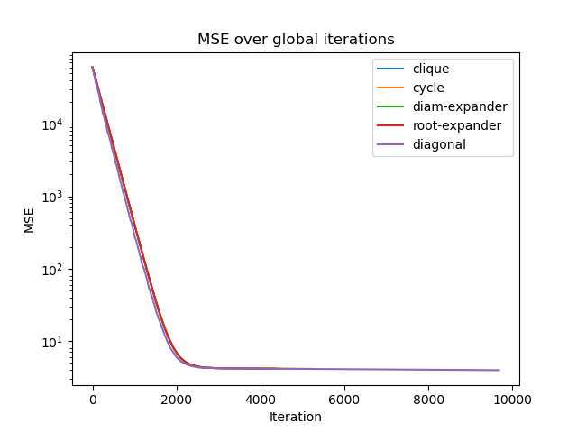

### 100k samples GD test - RMSE over iterations

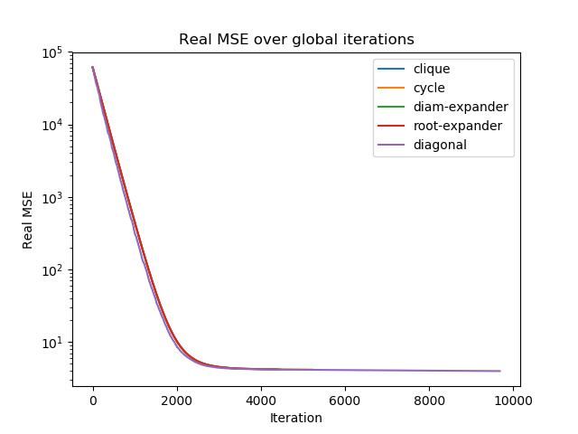

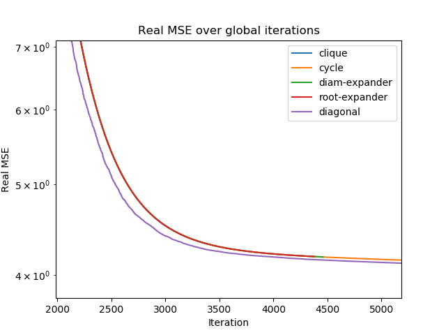

### 100k samples GD test - MSE over time

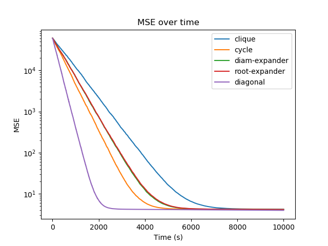

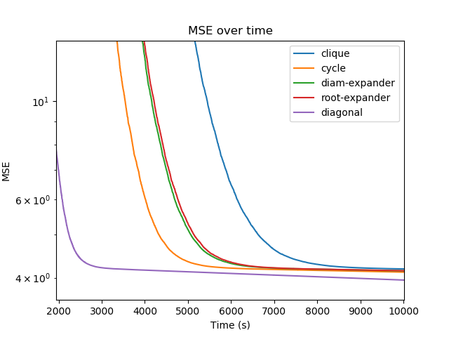

### 100k samples GD test - RMSE over time

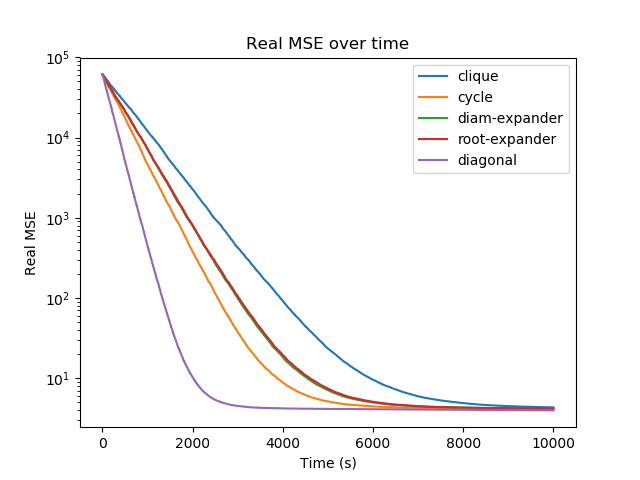

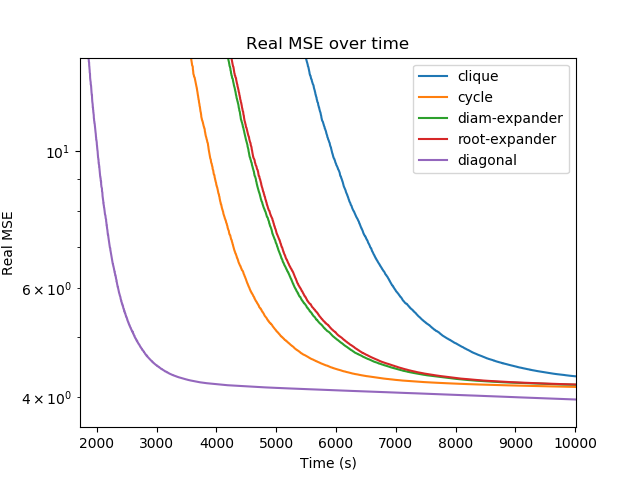

*The same test with different seeds has led to almost identical results.*

While the training set gets bigger, diagonal topology turns out to be by far the fastest. I would like to make some tests with different kinds of training sets to assess whether this results are strongly related to this training set morphology or can be extended to more general cases.